# Peak power and energy - 1 Aldrich St

This report details some concerns about the power generation of the solar array installed at 1 Aldrich St, Northampton, and activated April 7, 2023.

## Peak power

The designed maximum power generation of the system is just over 6kW. On the first three full days of operation, peak power of 6kW was sustained for several hours each day with over 45kWh generated each day.

This chart shows power clearly peaking at 6kW on April 8-10. April 20 comes close to this performance but does not match it.

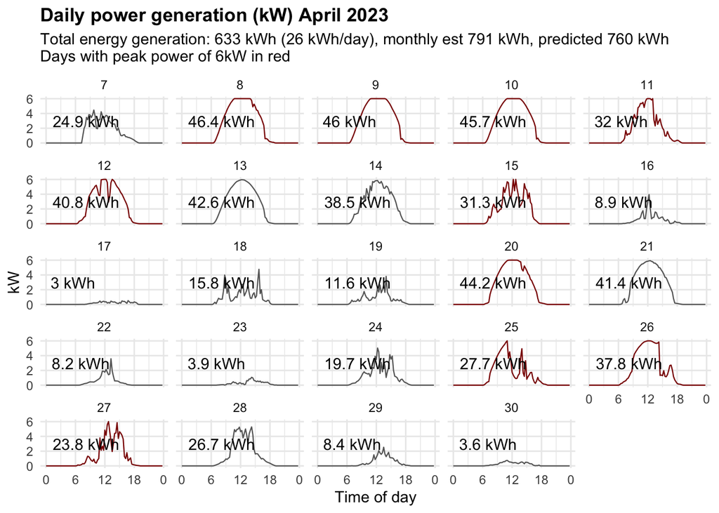

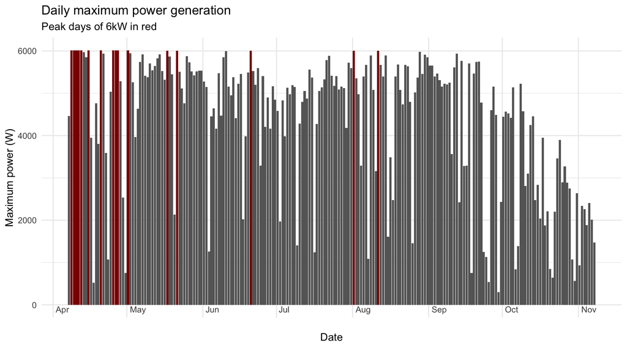

# Daily energy

A similar story is told by daily total energy production. April 8-10 saw more than 45kWh generated each day; this level has never been reached again.

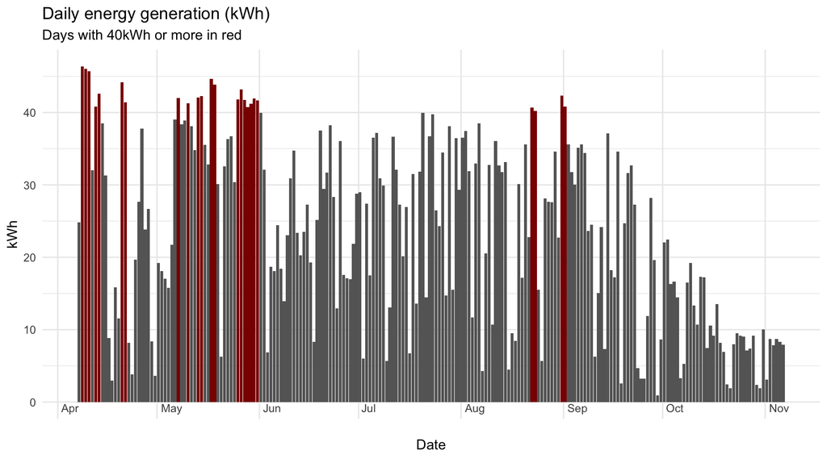

# Actual vs predicted

Comparing actual monthly energy generation with the predictions in the PV Squared proposal, May greatly exceeded the prediction; all subsequent months fell short.

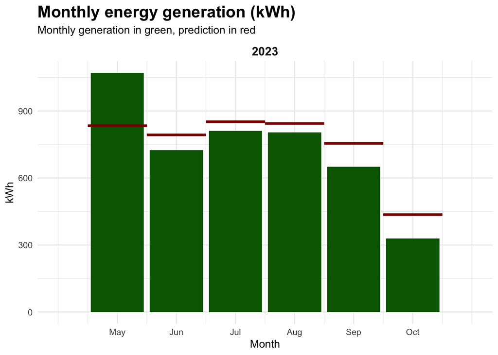

Actual and predicted energy generation

1 Aldrich St, 2023

|  | Month | kWh Predicted | kWh Actual | kWh Difference | Percent difference |  |
| --- | --- | --- | --- | --- | --- | --- |
|  | May | 834 | 1,070 | 236 |  | 28% |
|  | June | 793 | 725 | −68 | −9% |  |
|  | July | 852 | 810 | −42 | −5% |  |
|  | August | 844 | 804 | −40 | −5% |  |
|  | September | 755 | 651 | −104 | −14% |  |
|  | October | 436 | 329 | −107 | −25% |  |
| Total |  | 4,514 | 4,389 | −125 |  |  |